# Module-1 Assignment by “Sankalp Biswal”

# 2024-01-13

# Introduction:

The Ames Housing dataset offers a comprehensive analysis of residential homes in Ames, Iowa, from 2006 to 2010. In this study, we aimed to understand the factors influencing house prices and develop a predictive model for SalePrice, the property’s sale price. Through Exploratory Data Analysis (EDA), we summarized the dataset’s characteristics, addressed missing values, and examined correlations among variables. We plotted the distribution of SalePrice to understand its skewness and identify outliers. A rigorous statistical analysis was performed using correlation matrices and scatter plots to identify relationships between SalePrice and other features. We then proceeded to fit a linear regression model, considering multicollinearity and leveraging the Variance Inflation Factor (VIF) to refine our predictors. The model’s diagnostics were conducted using residual and leverage plots to detect outliers and influential points. By employing all-subsets regression, we identified the “best” model that balances model complexity with predictive power. This comprehensive analysis leads us to a conclusion that synthesizes our findings and provides actionable insights.

# Importing Libraries

```r
library(dplyr)
```

```r
library(ggplot2)
library(corrplot)
library(RColorBrewer)
library(car)
library(ggcorrplot)
library(tidyr)
library(leaps)
```

### Q1. Load the Ames housing dataset.

A1.

```r
df <- read.csv("AmesHousing.csv")
df<- df %>%
  select(-Order, -PID)
```

### Q2. Perform Exploratory Data Analysis and use descriptive statistics to describe the data.

A2.

1. We’ve used `summary()` for descriptive statistics

```r
summary(df)
```

```
##   MS.SubClass      MS.Zoning          Lot.Frontage       Lot.Area
##  Min.   : 20.00   Length:2930        Min.   : 21.00   Min.   :  1300
##  1st Qu.: 20.00   Class :character   1st Qu.: 58.00   1st Qu.:  7440
##  Median : 50.00   Mode  :character   Median : 68.00   Median :  9436
##  Mean   : 57.39                      Mean   : 69.22   Mean   : 10148
##  3rd Qu.: 70.00                      3rd Qu.: 80.00   3rd Qu.: 11555
##  Max.   :190.00                      Max.   :313.00   Max.   :215245
##                                      NA's   :490
##     Street             Alley            Lot.Shape         Land.Contour
##  Length:2930        Length:2930        Length:2930        Length:2930
##  Class :character   Class :character   Class :character   Class :character
##  Mode  :character   Mode  :character   Mode  :character   Mode  :character
##
##
##
##
##   Utilities          Lot.Config         Land.Slope        Neighborhood
##  Length:2930        Length:2930        Length:2930        Length:2930
##  Class :character   Class :character   Class :character   Class :character
##  Mode  :character   Mode  :character   Mode  :character   Mode  :character
##
##
##
##
##  Condition.1        Condition.2         Bldg.Type         House.Style
##  Length:2930        Length:2930        Length:2930        Length:2930
##  Class :character   Class :character   Class :character   Class :character
##  Mode  :character   Mode  :character   Mode  :character   Mode  :character
##
##
##
##
##   Overall.Qual     Overall.Cond     Year.Built   Year.Remod.Add
##  Min.   : 1.000   Min.   :1.000   Min.   :1872   Min.   :1950
##  1st Qu.: 5.000   1st Qu.:5.000   1st Qu.:1954   1st Qu.:1965
##  Median : 6.000   Median :5.000   Median :1973   Median :1993
##  Mean   : 6.095   Mean   :5.563   Mean   :1971   Mean   :1984
##  3rd Qu.: 7.000   3rd Qu.:6.000   3rd Qu.:2001   3rd Qu.:2004
##  Max.   :10.000   Max.   :9.000   Max.   :2010   Max.   :2010
##
```

[output cut: 105 more lines]

```
##  Length:2930        Length:2930        Min.   :    0.00   Min.   : 1.000
##  Class :character   Class :character   1st Qu.:    0.00   1st Qu.: 4.000
##  Mode  :character   Mode  :character   Median :    0.00   Median : 6.000
##                                        Mean   :   50.63   Mean   : 6.216
##                                        3rd Qu.:    0.00   3rd Qu.: 8.000
##                                        Max.   :17000.00   Max.   :12.000
##
##     Yr.Sold      Sale.Type         Sale.Condition       SalePrice
##  Min.   :2006   Length:2930        Length:2930        Min.   : 12789
##  1st Qu.:2007   Class :character   Class :character   1st Qu.:129500
##  Median :2008   Mode  :character   Mode  :character   Median :160000
##  Mean   :2008                                         Mean   :180796
##  3rd Qu.:2009                                         3rd Qu.:213500
##  Max.   :2010                                         Max.   :755000
##
```

- We’ve obtained descriptive statistics for our dataset and we can see that few variables have “NA” or “missing values” which we’ll deal with later in the assignment.
2. Plotting a histogram for “SalePrice”

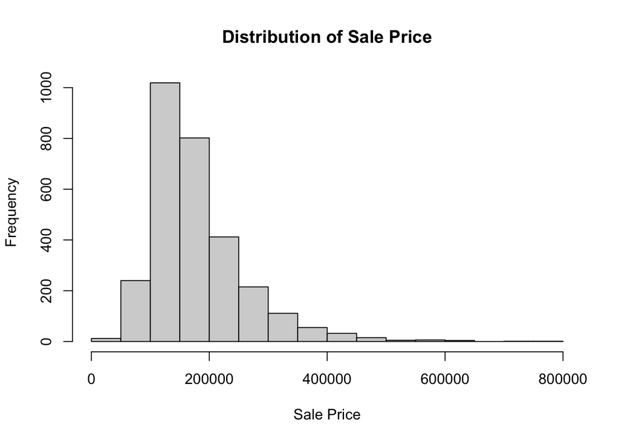

```r
options(scipen = 10)

hist(df$SalePrice, main = "Distribution of Sale Price", xlab = "Sale Price")
```

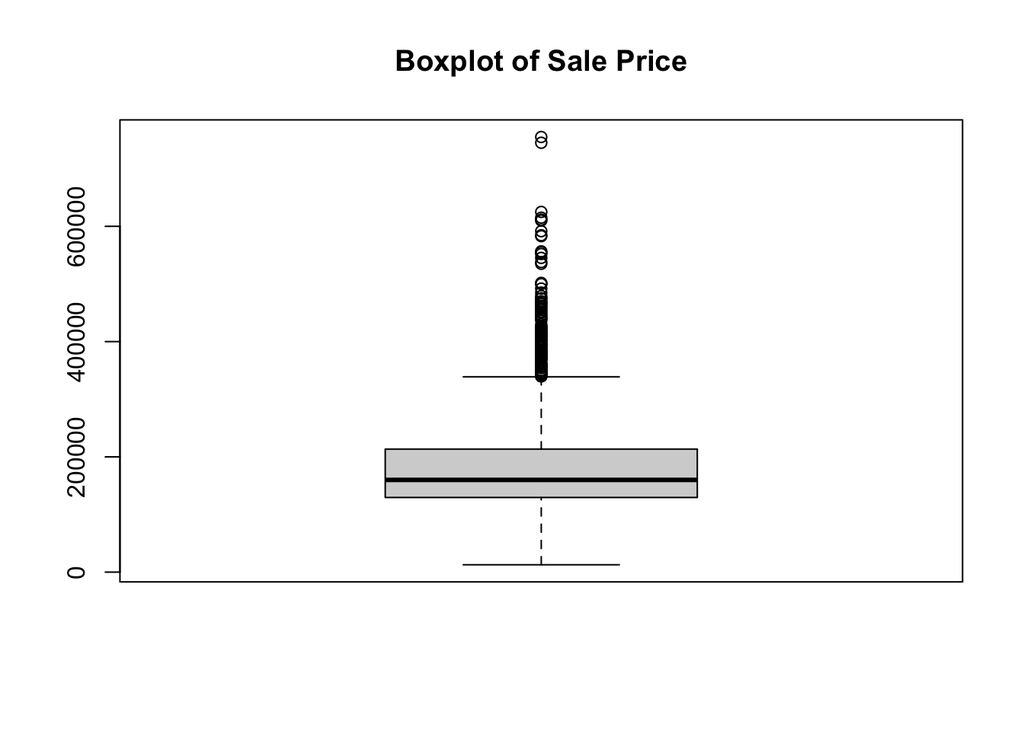

```r
# Boxplot of Sale Price
boxplot(df$SalePrice, main = "Boxplot of Sale Price")
```

- **Interpreting this boxplot for “Sale Price”:**
  - The distribution of sale prices is right-skewed, as evidenced by the median being closer to the bottom of the box and the long whisker extending upward with several outliers. This suggests that while the bulk of the sale prices are clustered at the lower end, there are quite a few houses that sold for much higher prices.
  - The presence of outliers indicates that there are some houses with sale prices significantly higher than typical values in the dataset. This could be due to a variety of factors such as location, size, or market conditions at the time of sale.
  - There are no outliers on the low end, suggesting that there are not many houses selling for exceptionally low prices relative to the rest of the data.

### Q3. Prepare the dataset for modeling by imputing missing values with the variable’s mean value or any other value that you prefer

A3.

1. We’ll impute any missing values in the dataset with the respective variable mean. (OpenAI, 2023)

   ```r
   # Impute missing values in numeric variables with mean
   numeric_cols <- sapply(df, is.numeric)

   df <- df%>%
     mutate_if(is.numeric, ~ ifelse(is.na(.), mean(., na.rm = TRUE), .))

   #For categorical columns----

   categorical_cols <- sapply(df, function(x) is.character(x) || is.factor(x))

   # Impute missing values in categorical columns with 'Unknown'
   df[, categorical_cols] <- lapply(df[, categorical_cols], function(x) {
     if (any(is.na(x))) {
       x <- replace(x, is.na(x), 'Unknown')
     }
     x
   })

   has_missing_values <- any(is.na(df))
   print(has_missing_values)
   ```

   ```
   ## [1] FALSE
   ```

### Q4. Use the cor() function to produce a correlation matrix of the numeric values.

A4. We’ve created a correlation matrix using `cor() for numeric values`

```r
# Extract numeric columns from the dataset
numeric_columns <- df[, sapply(df, is.numeric)]

# Create a correlation matrix
correlation_matrix <- cor(numeric_columns)
```

### Q5. Produce a correlation matrix plot, and explain how to interpret it. (hint - check the corrplot or ggcorrplot plot libraries)

A5. We’ve plotted a correlation matrix using `corrplot()`.

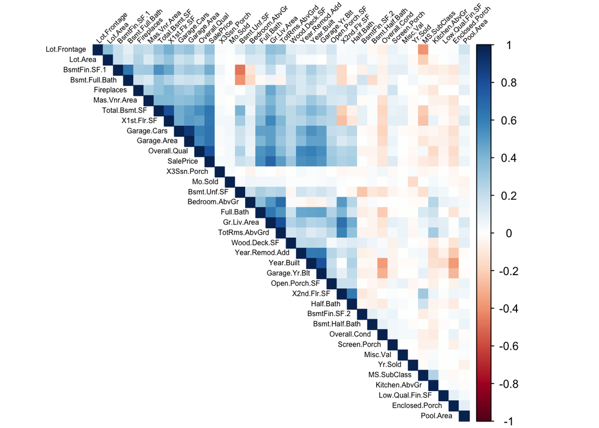

```r
corrplot(correlation_matrix,
         method = "color",
         type = "upper",
         order = "hclust",
         tl.col = "black",
         tl.srt = 45,
         tl.cex = 0.5,
         addrect = 3)
```

- **How to Interpret Specific Features of This Heatmap: (Statology, 2020)**
  - **Symmetry**: The matrix is symmetrical around the diagonal, meaning the correlation between **`X`** and **`Y`** is the same as between **`Y`** and **`X`**, so the matrix can be read either above or below the diagonal line.
  - **Strong Correlations**: Look for squares that are colored in dark blue or dark red to identify pairs of variables that have strong positive or negative correlations. These can suggest relationships that might be worth investigating further in your analysis.
  - **Weak/No Correlations**: Cells that are white or light in color indicate pairs of variables where there is a weak or no correlation.
  - **Potential Multicollinearity**: In the context of regression analysis, if two independent variables are highly correlated (dark blue), it could indicate multicollinearity, which might affect the performance of the model. It might be necessary to consider removing or combining these variables to mitigate the multicollinearity.
  - **Target Variable**: When analyzing a correlation matrix with the goal of predictive modeling, we often most interested in the column/row corresponding to the target variable (often **`SalePrice`** in real estate datasets) to see which features are most strongly correlated with the target.(OpenAI, 2023)

  In summary, this heatmap gives a quick visual overview of how all variables are related to each other, which can be very useful in the early stages of data analysis for identifying patterns, trends, and relationships within the data.

### Q6. Make a scatter plot for the X continuous variable with the highest correlation with SalePrice. Do the same for the X variable with the lowest correlation with SalePrice. Finally, make a scatter plot between X and SalePrice with the correlation closest to 0.5. Interpret the scatter plots and describe how the patterns differ.

A6. We’ll extract the variables with **highest**, **lowest** and **closest** correlation to **0.5** with the variable “*SalePrice*”.

```r
# Find the variable with the highest correlation
highest_corr_var <- names(sort(correlation_matrix["SalePrice", ], decreasing = TRUE)[2])
cat("Highest correlation with SalePrice is", highest_corr_var, "\n")
```

```
## Highest correlation with SalePrice is Overall.Qual
```

```r
# Find the variable with the lowest correlation
lowest_corr_var <- names(which.min(correlation_matrix["SalePrice", ]))

cat("Lowest correlation with SalePrice is", lowest_corr_var, "\n")
```

```
## Lowest correlation with SalePrice is Enclosed.Porch
```

```r
# Find the variable with correlation closest to 0.5
closest_corr_var <- names(which.min(abs(correlation_matrix[,"SalePrice"] - 0.5)))

cat("Correlation closest to 0.5 with SalePrice is", closest_corr_var, "\n")
```

```
## Correlation closest to 0.5 with SalePrice is TotRms.AbvGrd
```

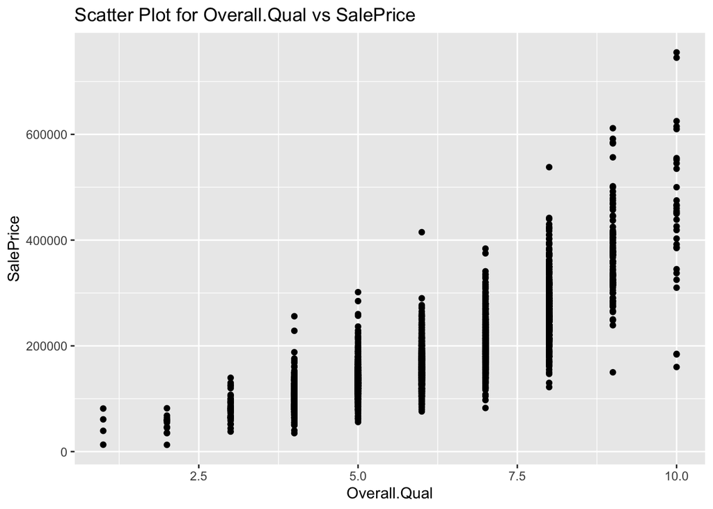

```r
# Scatter plot for the highest correlated variable with SalePrice
ggplot(df, aes_string(x = highest_corr_var, y = "SalePrice")) +
  geom_point() +
  ggtitle(paste("Scatter Plot for", highest_corr_var, "vs SalePrice"))
```

**SalePrice vs Overall.Qual:**

- This plot shows a defined positive correlation between the overall quality of the house and the sale price.
- As the overall quality rating increases, the sale price tends to increase as well, indicating that quality is an important factor in determining sale price.
- The range of sale prices widens with higher quality ratings, implying that higher-quality houses can vary more significantly in price, possibly due to additional features or premium finishes not captured by the quality rating alone.

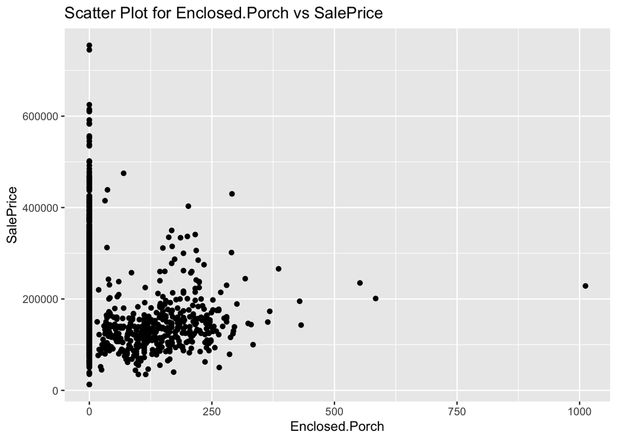

```r
# Scatter plot for the variable with the lowest correlation with SalePrice
ggplot(df, aes_string(x = lowest_corr_var, y = "SalePrice")) +
  geom_point() +
  ggtitle(paste("Scatter Plot for", lowest_corr_var, "vs SalePrice"))
```

**SalePrice vs Enclosed.Porch**:

- This scatter plot shows a weak to no apparent correlation between the size of the enclosed porch and the sale price.
- Most data points are clustered at the lower end of the enclosed porch size, suggesting that many houses do not have a large enclosed porch.
- There’s a wide spread in sale prices for houses with small to no enclosed porches, indicating that the enclosed porch size is not a strong predictor of sale price.

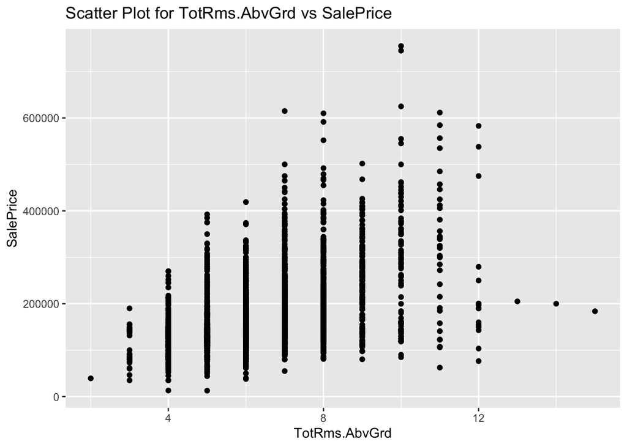

```r
# Scatter plot for the variable with correlation closest to 0.5 with SalePrice
ggplot(df, aes_string(x = closest_corr_var, y = "SalePrice")) +
  geom_point() +
  ggtitle(paste("Scatter Plot for", closest_corr_var, "vs SalePrice"))
```

**SalePrice vs TotRms.AbvGrd**:

- There is a positive correlation between the total number of rooms above ground and the sale price, although it’s not strictly linear.
- As the number of rooms increases, the range of sale prices also increases, suggesting that larger homes (with more rooms) have a higher variability in sale price.
- The vertical spread of points at each room count indicates variability in sale prices that could be attributed to other factors like location, size, or quality of the rooms.

**Differences in Patterns**:

- The plot for ‘Overall.Qual’ indicates a stronger relationship with ‘SalePrice’ than the other two variables. This suggests that quality is a stronger predictor of sale price.
- The ‘TotRms.AbvGrd’ scatter plot also shows a trend where more rooms may lead to a higher price, but the relationship isn’t as strong as with ‘Overall.Qual’.
- The ‘Enclosed.Porch’ scatter plot does not show a clear trend, suggesting that this feature may not have a significant impact on the sale price compared to the number of rooms or the overall quality.
- In summary, these scatter plots suggest that house quality and size (as indicated by the number of rooms) are more influential on the sale price than the presence of an enclosed porch. The ‘Overall.Qual’ plot indicates that higher quality correlates with higher sale prices, while ‘TotRms.AbvGrd’ suggests that larger homes with more rooms tend to sell for more. The ‘Enclosed.Porch’ plot does not show a significant relationship with sale price, indicating it may not be an important feature for predicting housing prices in this dataset.

### Q7. Fit a regression model in R, using at least 3 continuous variables.

A7. First, we’ll identify variables with high correlation values with respect to “*SalePrice*”

```r
# Identify the top 4 correlated variables with SalePrice
top_cor_vars <- names(sort(correlation_matrix["SalePrice", ], decreasing = TRUE)[2:5])
print(top_cor_vars)
```

```
## [1] "Overall.Qual" "Gr.Liv.Area"  "Garage.Cars"  "Garage.Area"
```

- Now, we’ll fit a **Linear regression model** using the variables obtained above

```r
regression_model <- lm(SalePrice ~ ., data = df[, c("SalePrice", top_cor_vars)])

summary(regression_model)
```

```
##
## Call:
## lm(formula = SalePrice ~ ., data = df[, c("SalePrice", top_cor_vars)])
##
## Residuals:
##     Min      1Q  Median      3Q     Max
## -397748  -21914   -1851   18954  293602
##
## Coefficients:
##                 Estimate  Std. Error t value Pr(>|t|)
## (Intercept)  -103815.381    3267.428 -31.773  < 2e-16 ***
## Overall.Qual   27996.905     700.746  39.953  < 2e-16 ***
## Gr.Liv.Area       50.862       1.803  28.214  < 2e-16 ***
## Garage.Cars     5584.510    2166.736   2.577     0.01 *
## Garage.Area       58.860       7.456   7.894  4.1e-15 ***
## ---
## Signif. codes:  0 '***' 0.001 '**' 0.01 '*' 0.05 '.' 0.1 ' ' 1
##
## Residual standard error: 39280 on 2925 degrees of freedom
## Multiple R-squared:  0.7586, Adjusted R-squared:  0.7583
## F-statistic:  2298 on 4 and 2925 DF,  p-value: < 2.2e-16
```

### Q8. Report the model in equation form and interpret each coefficient of the model in the context of this problem.

A8. I have fitted a regression model to predict “*SalePrice*” based on several variables. The equation of the model is as follows:

### Equation form:

SalePrice= −103,800+28,000×Overall Qual + 50.86×Gr Liv Area + 5,585×Garage Cars + 58.86×Garage Area

Now, let me interpret each coefficient in the context of the problem:

1. **Intercept (-103,800):**
   - The intercept represents the estimated SalePrice when all other predictor variables are zero. However, in our housing price prediction context, this might not have a meaningful interpretation.
2. **Overall Quality (28,000):**
   - For each unit increase in Overall Quality, I expect the SalePrice to increase by $28,000, holding other variables constant.
   - Pr(>|t|): < 2e-16 (Highly statistically significant)
3. **Ground Living Area (50.86):**
   - For each additional square foot increase in Ground Living Area, I expect the SalePrice to increase by $50.86, holding other variables constant.
   - Pr(>|t|): < 2e-16 (Highly statistically significant)
4. **Garage Cars (5,585):**
   - For each additional car capacity in the garage, I expect the SalePrice to increase by $5,585, holding other variables constant.
   - Pr(>|t|): 0.01 (Statistically significant)
5. **Garage Area (58.86):**
   - For each additional square foot increase in Garage Area, I expect the SalePrice to increase by $58.86, holding other variables constant.
   - Pr(>|t|): 4.1e-15 (Highly statistically significant)

In summary, all variables in the model have statistically significant coefficients. The *“Overall.Qual,” “Gr.Liv.Area,” and* “Garage.Area” variables are highly significant, while *“Garage.Cars”* is statistically significant but less so compared to the others. The Adjusted R sqaured value of 0.7583 indicates that approximately 75.83% of the variability in SalePrice can be explained by the model and indicates a good fit.

### Q9. Use the plot() function to plot your regression model. Interpret the four graphs that are produced.

A9. We’ve plotted 4 graphs using `plot()` and have interpreted the same. ("4.2 - Residuals Vs. Fits Plot | STAT 501," n.d.)

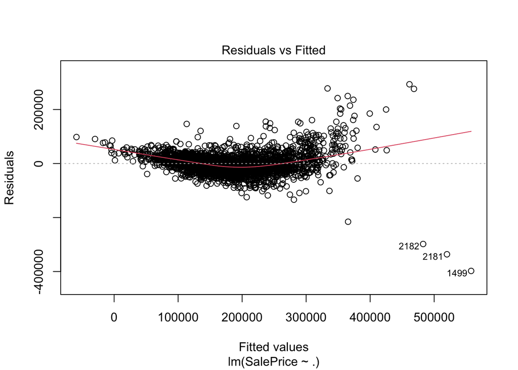

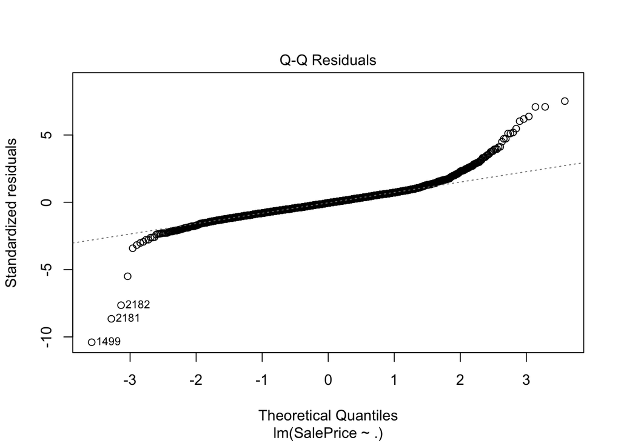

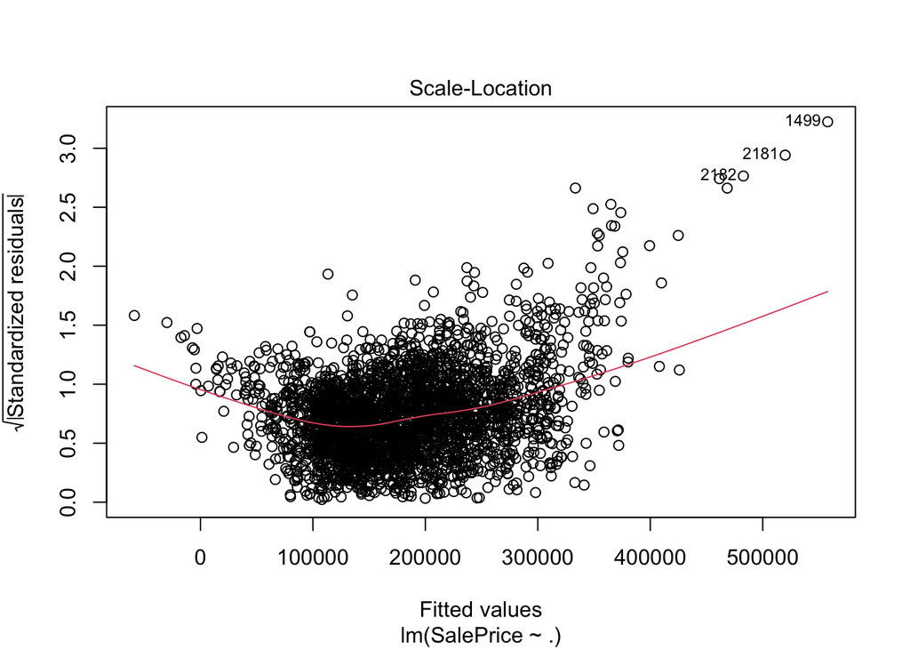

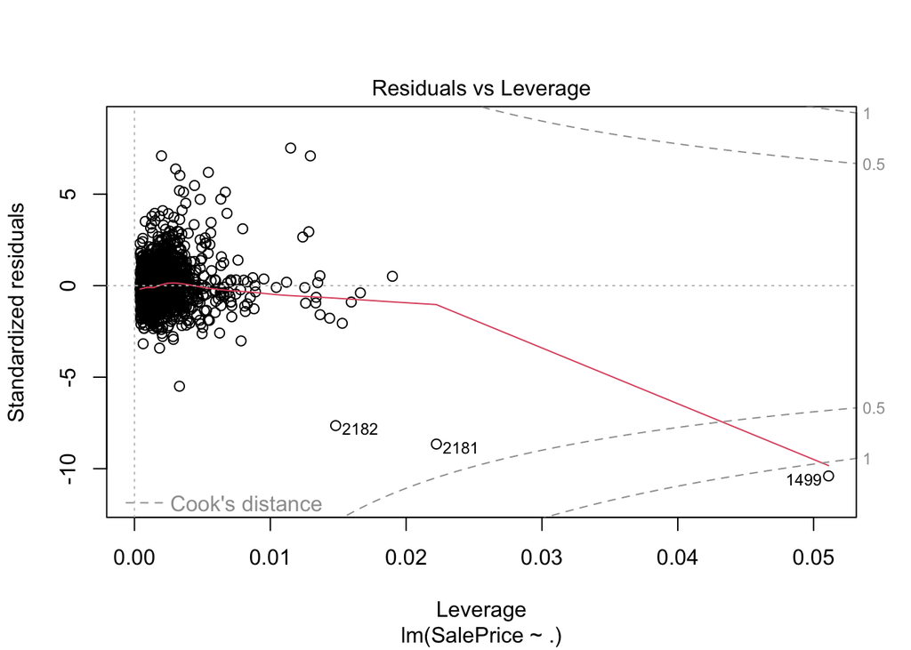

```r
plot(regression_model)
```

**Interpretation**:

1. **Residuals vs Leverage Plot**

   This plot helps to find influential cases (if any) in the regression model. The points far from zero on the x-axis (leverage) are points that have more “influence” on the regression equation. The Cook’s distance lines (dashed lines) help you identify these influential points. Points that are outside the dashed lines are considered to have high leverage.
2. **Scale-Location Plot**

   This plot shows how residuals are spread along the range of predictors. It’s used to check the assumption of equal variance (homoscedasticity). Ideally, the red line should be approximately horizontal at the value of 1 on the y-axis.
3. **Q-Q Plot (Quantile-Quantile Plot)**

   This plot shows if the residuals are normally distributed. Points following the dashed line suggest normality. Deviations from this line indicate departures from normality.
4. **Residuals vs Fitted Plot**

   This plot is used to check the assumption that the residuals do not have any systematic relationship with the fitted values, which would indicate non-linearity in the data. A horizontal line with randomly spread points around it suggests that the assumption is true.

In each of these plots, we see one or more points labeled, usually with an observation number. These are points that the diagnostic measures (like Cook’s distance) have identified as being potentially influential or outliers, and they warrant further investigation.

In summary, these plots are used to check for assumptions and potential problems in the regression model such as **non-linearity, non-constant variance, outliers, and influential data points**. The data points labeled in these plots are the ones that the model suggests should be looked at more closely.

### Q10. Check your model for multicollinearity and report your findings. What steps would you take to correct multicollinearity if it exists?

A10. We’ll use **Variance Inflation Factor (VIF)** for checking **multicollinearity.** (Team, 2023)

```r
# Check for multicollinearity using VIF
vif_results <- vif(regression_model)

# Print VIF values
print(vif_results)
```

```
## Overall.Qual  Gr.Liv.Area  Garage.Cars  Garage.Area
##     1.856219     1.576657     5.154375     4.879679
```

**Variance Inflation Factor (VIF)** is a measure that quantifies how much the variance of the estimated regression coefficients increases when your predictors are correlated. The interpretation of VIF values is as follows:

- **VIF = 1:**
  - No multicollinearity. This indicates that the predictor is not correlated with other predictors.
- **VIF > 1 but < 5:**
  - Moderate multicollinearity. This suggests some correlation with other predictors. This is generally acceptable.
- **VIF > 5:**
  - High multicollinearity. This indicates a problematic level of correlation with other predictors. This may lead to unreliable coefficient estimates.

**Interpretation:**

- Overall, Overall Quality and Ground Living Area have VIF values close to 1, indicating low multicollinearity.
- Garage.Area has VIF = 4.8 indicating moderate multicollinearity
- Garage.Cars has VIF = 5.15 indicating high multicollinearity

**Corrective Steps:**

- Removing variables with High **VIF**
- Removing Highly correlated Predictors
- Contextual consideration - In some cases, multicollinearity may not be a significant issue, especially if the goal is prediction rather than interpretation.
- I would remove Garage.Cars from the regression model due to high multicollinearity

### Q11. Check your model for outliers and report your findings. Should these observations be removed from the model?

A11. In order to check for model outliers, we’ll do **Residuals analysis** and **Residuals vs Leverage analysis**

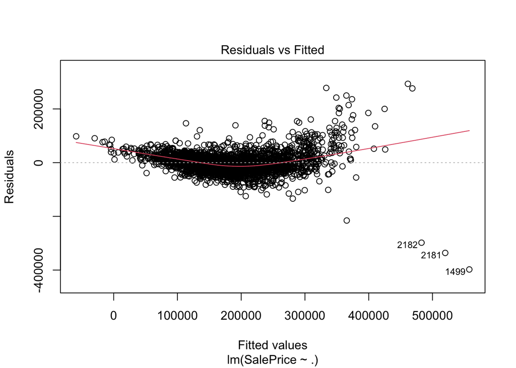

```r
# Assuming your model is named as 'regression_model'
plot(regression_model, which = 1) # Residuals vs Fitted
```

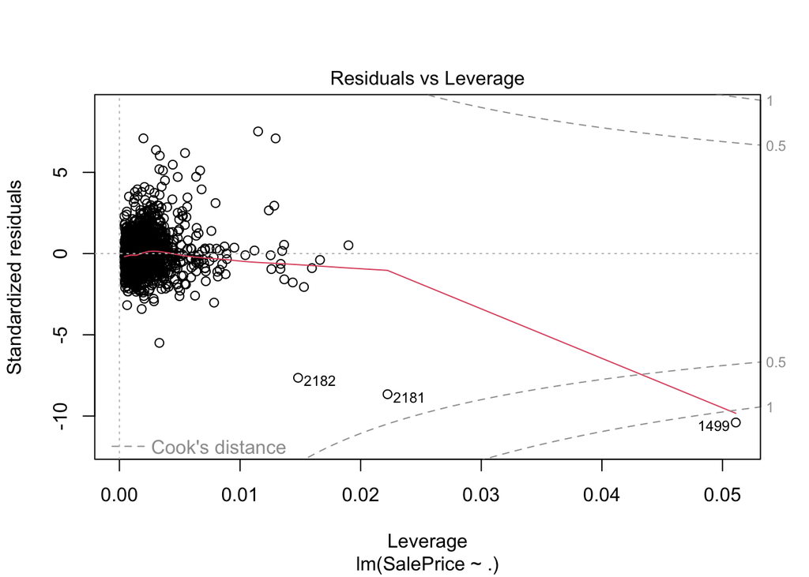

```r
plot(regression_model, which = 5) # Cook's Distance Plot
```

**Interpretation:**

1. **Residuals vs Fitted**

We’ll remove outliers based on cook’s distance which is the dotted line in the above graph.

```r
# Calculating Cook's Distance
cooks.distance <- cooks.distance(regression_model)

# Identifying potential outliers
potential_outliers <- which(cooks.distance > 4/(nrow(df)-length(coef(regression_model))))
```

### **Decision on Removing Outliers:**

- **Not Always Necessary:** Removing outliers is not always necessary. Sometimes, they represent valuable extremes in your data.
- **Context Matters:** The decision should be based on the context. If outliers represent errors or anomalies not relevant to the analysis, they can be removed.
- **Impact Assessment:** Assess the impact of outliers on model performance. If their inclusion significantly distorts the model, consider removing them.

  (OpenAI, 2023)

### Q12. Attempt to correct any issues that you have discovered in your model. Did your changes improve the model? Why or why not?

A.12

**Issues discovered in the model:**

1. Garage.Cars has VIF > 5, indicating high multicollinearity.
2. Garage.Cars has is statistically significant but not as much as the other variables.
3. Potential outliers have been detected using Cook’s distance

**Steps to take:**

1. Remove Garage.Cars from the model
2. Remove the outliers and check if model performs any better

```r
df_clean <- df[-potential_outliers, ]

new_vars <- select(df_clean,"Overall.Qual", "Gr.Liv.Area","Garage.Area", "SalePrice")

regression_model <- lm(SalePrice ~ ., data = new_vars)

summary(regression_model)
```

```
##
## Call:
## lm(formula = SalePrice ~ ., data = new_vars)
##
## Residuals:
##     Min      1Q  Median      3Q     Max
## -118280  -17277   -1066   17073  107386
##
## Coefficients:
##                Estimate Std. Error t value Pr(>|t|)
## (Intercept)  -81275.833   2506.519  -32.43   <2e-16 ***
## Overall.Qual  24160.729    514.161   46.99   <2e-16 ***
## Gr.Liv.Area      51.141      1.419   36.04   <2e-16 ***
## Garage.Area      74.945      3.187   23.51   <2e-16 ***
## ---
## Signif. codes:  0 '***' 0.001 '**' 0.01 '*' 0.05 '.' 0.1 ' ' 1
##
## Residual standard error: 27230 on 2759 degrees of freedom
## Multiple R-squared:  0.818,  Adjusted R-squared:  0.8178
## F-statistic:  4133 on 3 and 2759 DF,  p-value: < 2.2e-16
```

**Interpretation:**

In summary, the new model has a lower residual standard error, higher R-squared values, and a higher F-statistic compared to the old model. These improvements indicate that the new model is a better fit for the data and provides more accurate predictions of *SalePrice.*

### Q13. Identify the “best” model using the all-subsets regression method. State the preferred model in equation form.

A13. We’ll perform all-subsets regression to find out which subset of predictor variables gives us the best accuracy. (OpenAI, 2023)

```r
# Define predictors
predictors <- c("Overall.Qual", "Gr.Liv.Area", "Garage.Area")
# Subset the relevant predictors and response variable
data_subset <- subset(df_clean, select = c("SalePrice", predictors))
# Generate all subsets of the predictors up to 3 variables
models <- regsubsets(SalePrice ~ ., data = data_subset, nvmax = 3)

summary(models)
```

```
## Subset selection object
## Call: regsubsets.formula(SalePrice ~ ., data = data_subset, nvmax = 3)
## 3 Variables  (and intercept)
##              Forced in Forced out
## Overall.Qual     FALSE      FALSE
## Gr.Liv.Area      FALSE      FALSE
## Garage.Area      FALSE      FALSE
## 1 subsets of each size up to 3
## Selection Algorithm: exhaustive
##          Overall.Qual Gr.Liv.Area Garage.Area
## 1  ( 1 ) "*"          " "         " "
## 2  ( 1 ) "*"          "*"         " "
## 3  ( 1 ) "*"          "*"         "*"
```

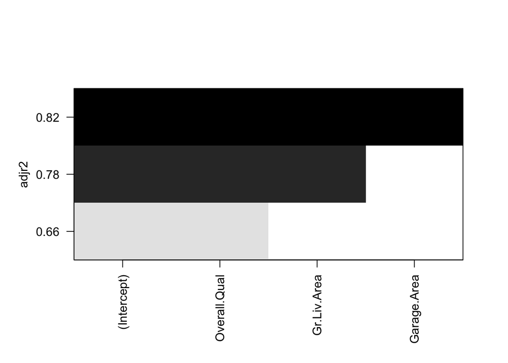

```r
# Plot a table of models showing variables in each model ordered by the selection statistic (adjusted R2)
plot(models, scale = "adjr2")
```

**Interpretation:**

- **Bars**: Each bar represents a model with a different combination of predictors. The length of the bar indicates the value of the adjusted R-squared for that model.
- **Black and Grey Scale**: The filled part of the bar (in black or grey) indicates the predictors that are included in the model. A filled block under a predictor name means that the predictor is included in the model corresponding to that bar.
- **Adjusted R-squared (adjr2)**: The adjusted R-squared is a modified version of R-squared that has been adjusted for the number of predictors in the model. It provides a measure of how well the model fits the data while penalizing for the number of predictors.
- **(Intercept)**: This is the baseline of the model. It is always included since it represents the constant term in the regression equation.

**Interpreting the graph above, it appears that:**

- The model with the **highest adjusted R-squared** includes all three predictors: **`Overall.Qual`**, **`Gr.Liv.Area`**, and **`Garage.Area`**.
- The black bar reaches the highest on the scale of adjusted R-squared, suggesting that the model with all three predictors has the best fit among the models considered, after adjusting for the number of predictors.
- The length of the bars decreases as the number of predictors decreases, indicating that models with fewer predictors have lower adjusted R-squared values.

In conclusion, based on the adjusted R-squared values, the model with **`Overall.Qual`**, **`Gr.Liv.Area`**, and **`Garage.Area`** is preferred because it has the highest adjusted R-squared, suggesting it provides the best balance between model complexity (number of predictors) and fit.

### Equation form of preferred model :

SalePrice= −81275.833+24160.729×Overall.Qual + 51.141×Gr.Liv.Area + 74.945×Garage.Area

### Q14. Compare the preferred model from step 13 with your model from step 12. How do they differ? Which model do you prefer and why?

A14. The preferred model in Ques13 and model selected in Ques12 are the same. Both the models have 3 predictor variables and give the best Adjusted R-squared value when all the 3 variables are selected together.

# Conclusion

Our analysis of the Ames Housing dataset led to an understanding of the housing market factors. Our final model, based on Overall Quality, Ground Living Area, and Garage Area, accounted for approximately 81.8% of the variance in SalePrice, indicating a strong model fit. The all-subsets regression method confirmed these three variables as the optimal predictors. This model outperformed the initial models, which included variables that exhibited high multicollinearity. Upon comparing the models, we observed that removing Garage Cars and addressing outliers improved the predictive power and accuracy of our model. The preferred model not only provides a quantifiable measure of house valuation but also reflects the significant impact of a house’s quality, size, and garage area on its sale price. This model can serve as a robust tool for potential buyers, sellers, and investors in the Ames housing market.

# References

1. OpenAI. (2021). ChatGPT (Version 3.5). OpenAI.https://chat.openai.com/
2. Z. (2023, February 8). How to Read a Correlation Matrix. Retrieved from https://www.statology.org/how-to-read-a-correlation-matrix/
3. 4.2 - Residuals vs. Fits Plot | STAT 501. (n.d.). Retrieved from https://online.stat.psu.edu/stat501/lesson/4/4.2
4. Team, I. (2023, October 1). Variance Inflation Factor (VIF). Retrieved from https://www.investopedia.com/terms/v/variance-inflation-factor.asp